# Data Sourcing

### Some General Trends

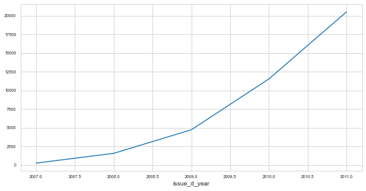

```python
#Loan amount count over the years
plt.figure(figsize=(10,5))
loan.groupby('issue_d_year').loan_amnt.count().plot(kind='line', fontsize=7)
plt.show()
```

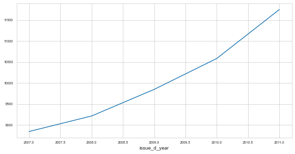

```python
#Average Loan amount over the years
plt.figure(figsize=(10,5))
loan.groupby('issue_d_year').loan_amnt.mean().plot(kind='line', fontsize=7)
plt.show()
```

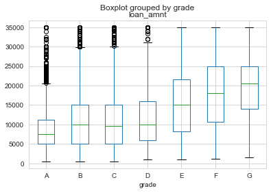

```python
#Distribution of loan amount over Grade
loan.boxplot(column='loan_amnt', by='grade')
plt.show()
```

- It seems that apparently lower grade is given to Large loan amounts.
- Its very evident from graph that as median loan amount increases corresponding grades given are decreasing

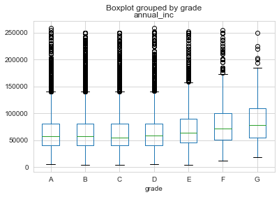

```python
#Distribution of annual income over Grade
loan.loc[loan['annual_inc']<260000].boxplot(column='annual_inc', by='grade')
plt.show()
```

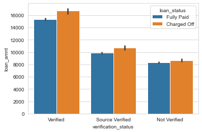

```python
sns.barplot(x='verification_status', y='loan_amnt', hue="loan_status", data=loan, estimator=np.mean)
```

- Higher loan amounts are Verified more often.
- Higher loan amounts are riskier and are also verified more often.

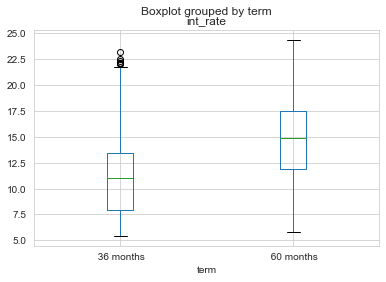

```python
#Interest vs Term
loan.boxplot(column='int_rate', by='term')
plt.show()
```

- Seems like large amounts are having longer term and hece the intrest associated with them is also high.

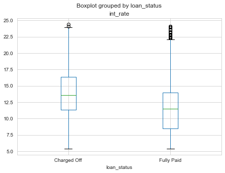

```python
#Loan Status vs Int rate
loan.boxplot(column='int_rate', by='loan_status',figsize=(7,5))
```

- Seems like Loans at a higher intrest rate are more likely to be defaulted.

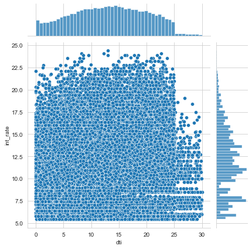

```python
sns.jointplot('dti', 'int_rate', loan)
```

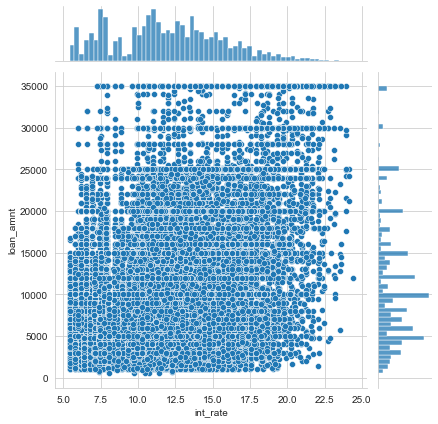

```python
sns.jointplot('int_rate', 'loan_amnt', loan)
```